# Introduction

In this validation we wanted to test if insertion was correctly implemented.

version: invadego 0.1.3

### Materials & Methods

| Bias | SampleID | Seed |
| --- | --- | --- |
| -100 | mb100 | 1687986419473565499 |
| -90 | mb90 | 1687986439519204740 |
| -80 | mb80 | 1687986459385010207 |
| -70 | mb70 | 1687986479004319218 |
| -60 | mb60 | 1687986498415164945 |
| -50 | mb50 | 1687986518191731481 |
| -40 | mb40 | 1687986537947039053 |
| -30 | mb30 | 1687986557979563694 |
| -20 | mb20 | 1687986577799895192 |
| -10 | mb10 | 1687986597553426300 |
| 0 | b0 | 1687986617358973799 |
| 10 | b10 | 1687986636894417837 |
| 20 | b20 | 1687986656418196570 |
| 30 | b30 | 1687986677115413538 |
| 40 | b40 | 1687986698520036068 |
| 50 | b50 | 1687986720075130951 |
| 60 | b60 | 1687986741333869430 |
| 70 | b70 | 1687986762991078587 |
| 80 | b80 | 1687986784961325051 |
| 90 | b90 | 1687986806594066852 |
| 100 | b100 | 1687986827704107589 |

## Bash Command for Simulation

```bash
tool="./main"
genome="mb:1,1,1,1,1"
cluster="kb:30,30,30,30,30"
rep=100
gen=1
steps=1
folder="Simulation-Results/Insertion-Bias/validation_7"
rr="0,0,0,0,0"

mkdir -p $folder

# Loop over values from -100 to 100 in steps of 10
for j in $(seq -100 10 100)
do
    # Set basepop directly to "1000;j"
    basepop="1000($j)"

    # Assign current counter value to sampleid with descriptive prefix
    if [ $j -ge 0 ]
    then
        sampleid="b${j}"
    else
        sampleid="mb${j#-}"  # Use parameter expansion to remove the negative sign
    fi

    # Run the command and write the output to a file named after the sampleid
    $tool --N 100000 --gen $gen --genome $genome --cluster $cluster --rr $rr --rep $rep --basepop "$basepop" --steps $steps --sampleid $sampleid > "$folder/result_${sampleid}.out"
done

cat result_*.out | grep -v "^Invade" | grep -v "^#" > combined_results.out
```

## Load and Clean Data

```r
# Load necessary libraries
library(readr)
library(dplyr)
library(ggplot2)

# Define column names
column_names <- c("rep", "gen", "popstat", "spacer_1", "fwte", "avw", "min_w", "avtes", "avpopfreq",
                "fixed", "spacer_2", "phase", "fwcli", "avcli", "fixcli", "spacer_3",
                "avbias", "3tot", "3cluster", "spacer_4", "sampleid")

# Load DataFrame with column names
df <- read_delim('Simulation-Results_Files/validation_7/combined_results.out', delim='\t', col_names = column_names)


# Define replacement dictionary
replace_dict <- c("mb100" = "-100","mb90" = "-90", "mb80" = "-80", "mb70" = "-70", "mb60" = "-60",
                "mb50" = "-50", "mb40" = "-40", "mb30" = "-30", "mb20" = "-20",
                "mb10" = "-10", "b100" = "100","b90" = "90", "b80" = "80", "b70" = "70",
                "b60" = "60", "b50" = "50", "b40" = "40", "b30" = "30",
                "b20" = "20", "b10" = "10", "b0" = "0")

# Apply replacements to 'sampleid' column
df$sampleid <- as.character(df$sampleid) %>% str_replace_all(replace_dict)

# Convert the columns to numeric
numeric_columns <- c("rep", "gen", "fwte", "avw", "min_w", "avtes", "avpopfreq",
                   "fixed", "fwcli", "avcli", "fixcli",
                   "avbias", "sampleid")

df[numeric_columns] <- lapply(df[numeric_columns], function(x) as.numeric(as.character(x)))

# Define your function
pc <- function(bias, clufrac) {
    genfrac = 1.0 - clufrac
    bias = bias / 100
    clufit = (bias + 1.0) / 2.0
    genfit = 1.0 - clufit
    totfit = clufrac * clufit + genfrac * genfit
    p = (clufrac * clufit) / totfit
    return(p * 100)
}

# Filter dataframe where 'gen' == 0 and sort it by 'sampleid'
df2 <- df[df$gen == 0, numeric_columns] %>% arrange(sampleid)

# Calculate the expected values (pc) for each 'sampleid'
df2$pc <- sapply(df2$sampleid, function(x) pc(x, 0.03))
```

## Plot Data

#### Figure 1 A

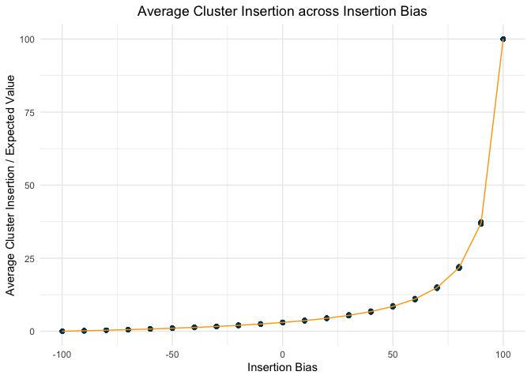

```r
a <- ggplot(df2, aes(x = sampleid)) +
  geom_point(aes(y = avcli), color = "#003f5c") +
  geom_line(aes(y = pc), color = "#ffa600") +
  labs(title = "Average Cluster Insertion across Insertion Bias",
       x = "Insertion Bias",
       y = "Average Cluster Insertion / Expected Value") +
  theme_minimal() +
  theme(plot.title = element_text(hjust = 0.5))

ggsave(
  filename = "images/Validation_7_1A.jpeg",
  plot = a,
  width = 10,
  height = 10,
  units = "in"
)
ggsave(
  filename = "images/Validation_7_1A.pdf",
  plot = a,
  width = 10,
  height = 10,
  units = "in"
)
plot(a)
```

The distribution of average TE (Transposable Elements) insertions across different insertion bias levels for all replicates. The x-axis shows the different Insertion Bias levels ranging from -100 to 100. The y-axis represents the average TE insertions in the piRNA Cluster (Blue Dots for Observed Value and Orange line for Expected value) for each bias level.

#### Figure 1 B

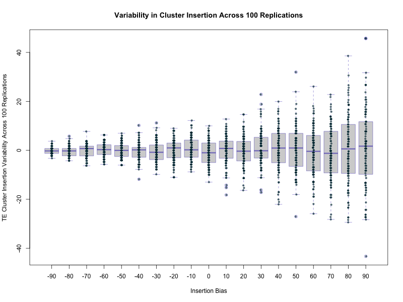

```r
# Filter out the group with sampleid = 100 and -100
df_filtered <- df2 %>%
  filter(!(sampleid %in% c(-100, 100)))

# Subtract 'pc' from 'avcli' and force as numeric
df_filtered$TE_insertions <- as.numeric(as.character(df_filtered$avcli)) - as.numeric(as.character(df_filtered$pc))
df_filtered$TE_insertions <- 100 * df_filtered$TE_insertions

# Convert 'sampleid' to factor
df_filtered$insertion_bias <- as.factor(df_filtered$sampleid)

# Create a new plot file with larger dimensions
png(filename = "images/Validation_7_1B.png", width = 800, height = 600)

# Boxplot
boxplot(df_filtered$TE_insertions ~ df_filtered$insertion_bias,
  border = rgb(0.1, 0.1, 0.7, 0.5),
  main = "Variability in Cluster Insertion Across 100 Replications",
  xlab = "Insertion Bias",
  ylab = "TE Cluster Insertion Variability Across 100 Replications")




# Add data points
mylevels <- levels(df_filtered$insertion_bias)
levelProportions <- summary(df_filtered$insertion_bias)/nrow(df_filtered)
for(i in 1:length(mylevels)){
  thislevel <- mylevels[i]
  thisvalues <- df_filtered[df_filtered$insertion_bias==thislevel, "TE_insertions"]

  # Ensure thisvalues is a numeric vector
  thisvalues <- unlist(thisvalues)

  # Take the x-axis indices and add a jitter, proportional to the N in each level
  myjitter <- jitter(rep(i, length(thisvalues)), amount=levelProportions[i]/2)

  # Use smaller points
  points(myjitter, thisvalues, pch=20, cex=0.9, col=rgb(0,0.2,0.25,0.6))
}



# Close the plot file
invisible(dev.off())
```

$$TE_{insertions} = 100 * (avcli-
pc)$$

The ‘Insertion Bias’ variable, represented on the x-axis, corresponds to the ‘sampleid’ column. It was converted to a factor variable to accommodate the categorical nature of this variable. The boxplot summarizes the distribution of ‘TE_insertions’ for each level of ‘Insertion Bias’. Each boxplot indicates the median, interquartile range, and potential outliers. The individual data points overlaid on the boxplots represent the variability in TE insertions.

#### Figure 2 A

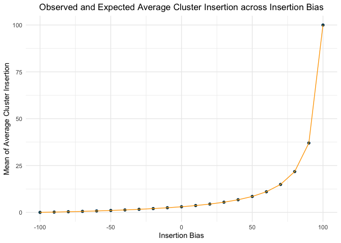

```r
# Calculate mean_cli, sd_meancli, pc, and deviation_pc
df_summary <- df2 %>%
    group_by(sampleid) %>%
    summarise(mean_cli = mean(avcli, na.rm = TRUE),
              sd_meancli = sd(avcli, na.rm = TRUE)) %>%
    mutate(pc = sapply(sampleid, function(x) pc(x, 0.03)),
           deviation_pc = mean_cli - pc)

# Create scatter plot with error bars
c <- ggplot(df_summary, aes(x = sampleid)) +
  geom_point(aes(y = mean_cli), color = "#003f5c") +
  geom_errorbar(aes(ymin = mean_cli - sd_meancli, ymax = mean_cli + sd_meancli), width = .2, color = "003f5c") +
  geom_line(aes(y = pc), color = "#ffa600") +
  labs(title = "Observed and Expected Average Cluster Insertion across Insertion Bias",
       x = "Insertion Bias",
       y = "Mean of Average Cluster Insertion") +
  theme_minimal() +
  theme(plot.title = element_text(hjust = 0.5))
ggsave(filename = "images/Validation_7_1C.png", plot = c, width = 10, height = 10, units = "in")
ggsave(filename = "images/Validation_7_1C.pdf", plot = c, width = 10, height = 10, units = "in", device = "pdf")
print(c)
```

#### Figure 2 B

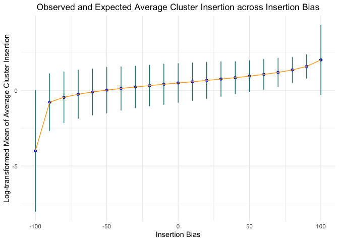

```r
# Transform the 'mean_cli' and 'sd_meancli' by taking log10 to visualize better.
# We add a small constant to avoid log(0) and handle negative values.
# Apply a logarithmic transformation to 'mean_cli', 'sd_meancli', and 'pc'
df_summary$log_mean_cli <- log10(df_summary$mean_cli + 0.0001)
df_summary$log_sd_meancli <- log10(df_summary$sd_meancli + 0.0001)
df_summary$log_pc <- log10(df_summary$pc + 0.0001)

# Create scatter plot with error bars
d <- ggplot(df_summary, aes(x = sampleid)) +
    geom_point(aes(y = log_mean_cli), color = "blue") +
    geom_errorbar(aes(ymin = log_mean_cli - log_sd_meancli, ymax = log_mean_cli + log_sd_meancli), width = .2, color = "#008080") +
    geom_line(aes(y = log_pc), color = "orange") +
    labs(title = "Observed and Expected Average Cluster Insertion across Insertion Bias",
         x = "Insertion Bias",
         y = "Log-transformed Mean of Average Cluster Insertion") +
    theme_minimal() +
    theme(plot.title = element_text(hjust = 0.5))

# Print the plot

ggsave(filename = "images/Validation_7_1D.png", plot = d, width = 10, height = 10, units = "in")
print(d)
```

#### Figure 3

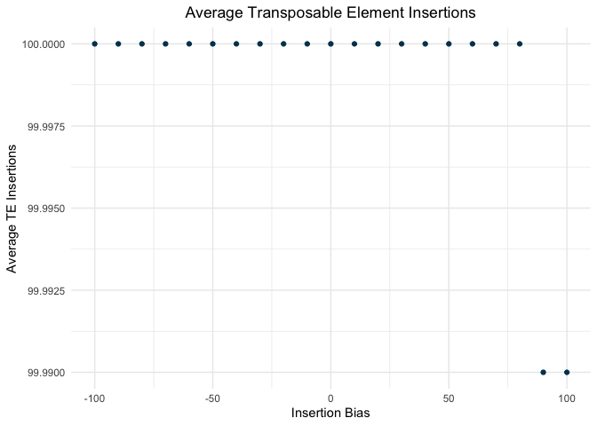

```r
# Filter for rep 1
df_rep1 <- df2[df2$rep == 1, ]

# Create scatter plot
e <- ggplot(df_rep1, aes(x = sampleid, y = avtes)) +
  geom_point(color = "#003f5c") +
  labs(title = "Average Transposable Element Insertions",
       x = "Insertion Bias",
       y = "Average TE Insertions") +
  theme_minimal() +
  theme(plot.title = element_text(hjust = 0.5))

ggsave(filename = "images/Validation_7_1E.png", plot = e, width = 10, height = 10, units = "in")
print(e)
```

Average TE insertions (y-axis) and insertion bias (x-axis) for a single replicate . The x-axis represents the Insertion Bias varying from -100 to 100. The y-axis depicts the average TE insertions for each bias level. Each data point on the graph represents the average TE insertions for a specific bias level for replicate 1.

#### Figure 4

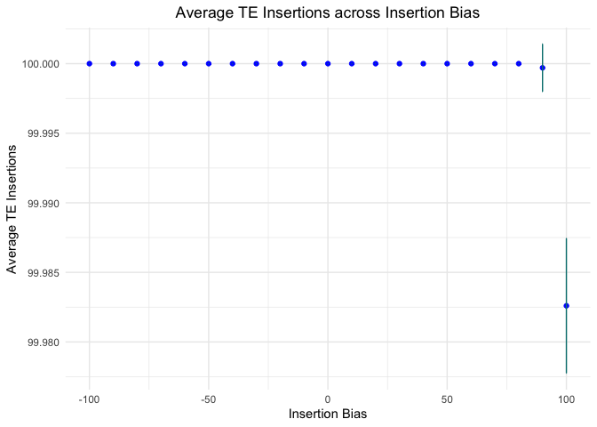

```r
# Calculate mean and standard deviation of avtes
df_summary_2 <- df2 %>%
    group_by(sampleid) %>%
    summarise(mean_avtes = mean(avtes, na.rm = TRUE),
              sd_avtes = sd(avtes, na.rm = TRUE))

# Create scatter plot with error bars
f <- ggplot(df_summary_2, aes(x = sampleid)) +
    geom_point(aes(y = mean_avtes), color = "blue") +
    geom_errorbar(aes(ymin = mean_avtes - sd_avtes, ymax = mean_avtes + sd_avtes), width = .2, color = "#008080") +
    labs(title = "Average TE Insertions across Insertion Bias",
         x = "Insertion Bias",
         y = "Average TE Insertions") +
    theme_minimal() +
    theme(plot.title = element_text(hjust = 0.5))

ggsave(filename = "images/Validation_7_1F.png", plot = a, width = 10, height = 10, units = "in")
print(f)
```

All replicates’ mean average TE insertions (y-axis) against the insertion bias (x-axis). The plot includes error bars, which visually represent the variability in the data by displaying the standard deviation for the average TE insertions at each bias level. The x-axis represents the Insertion Bias, which ranges from -100 to 100. The y-axis depicts the mean of the average TE insertions for each bias level. Each data point on the graph represents the mean average TE insertions for a specific bias level across all replicates, with the error bars representing the standard deviation.

# Summary of Average Cluster Insertion Statistics

```r
# Define your function
pc <- function(bias, clufrac) {
    genfrac <- 1.0 - clufrac
    bias <- bias / 100
    clufit <- (bias + 1.0) / 2.0
    genfit <- 1.0 - clufit
    totfit <- clufrac * clufit + genfrac * genfit
    p <- (clufrac * clufit) / totfit
    return(p * 100)
}
```

We create a new dataframe where ‘gen’ equals 0 and sort it by ‘sampleid’. Then we calculate the expected values (pc) for each ‘sampleid’.

```r
# Filter dataframe where 'gen' equals 0 and sort it by 'sampleid'
df2 <- df[df$gen == 0, numeric_columns] %>% arrange(sampleid)

# Calculate the expected values (pc) for each 'sampleid'
df2$pc <- sapply(df2$sampleid, function(x) pc(x, 0.03))
```

The last column, deviation_pc, is calculated as the deviation of mean_cli from pc as follows:

```r
# Calculate mean_cli, sd_meancli, pc, and deviation_pc
df_summary <- df2 %>%
    group_by(sampleid) %>%
    summarise(mean_cli = mean(avcli, na.rm = TRUE),
              sd_meancli = sd(avcli, na.rm = TRUE)) %>%
    mutate(pc = sapply(sampleid, function(x) pc(x, 0.03)),
           deviation_pc = mean_cli - pc)

print(tibble(df_summary), n=21)
```

```
## # A tibble: 21 × 5
##    sampleid mean_cli sd_meancli      pc deviation_pc
##       <dbl>    <dbl>      <dbl>   <dbl>        <dbl>
##  1     -100    0        0         0         0
##  2      -90    0.162    0.0130    0.163    -0.000814
##  3      -80    0.341    0.0204    0.342    -0.00157
##  4      -70    0.542    0.0248    0.543    -0.000423
##  5      -60    0.769    0.0297    0.767     0.00154
##  6      -50    1.02     0.0307    1.02     -0.00111
##  7      -40    1.30     0.0360    1.31     -0.00454
##  8      -30    1.63     0.0417    1.64     -0.00397
##  9      -20    2.02     0.0448    2.02     -0.00160
## 10      -10    2.48     0.0459    2.47      0.00719
## 11        0    2.99     0.0514    3        -0.00930
## 12       10    3.64     0.0571    3.64      0.000316
## 13       20    4.43     0.0622    4.43     -0.00360
## 14       30    5.44     0.0707    5.43      0.00955
## 15       40    6.73     0.0861    6.73      0.00333
## 16       50    8.50     0.0932    8.49      0.00513
## 17       60   11.0      0.0994   11.0      -0.00867
## 18       70   14.9      0.112    14.9      -0.0104
## 19       80   21.8      0.144    21.8       0.00271
## 20       90   37.0      0.164    37.0       0.0114
## 21      100  100.       0.00485 100        -0.0174
```

# Conclusion

The validation matches our expectations and the insertion is working as expected and the the simulation successfully incorporates the user-defined TE insertions as specified.